# Consistent sizing of your boxplots

Author

Steve Simon

Published

November 12, 2025

I wanted to show a series of boxplots comparing how a continuous outcome changes for different levels of a categorical variable. The categorical variable sometimes had two levels, sometimes four, and sometimes 6. I wanted the boxplots to be horizontal and fairly narrow. I hate fat boxplots.

## Calculations for a single boxplot

It’s tricky. Through a bit of trial and error, I discovered that R sets a fixed amount of white space above the top of the plotting area and below the bottom of the plotting area. On my system this is about 20 pixels and 60 pixels respectively. This would change if I put a title or a footnote on the graph.

I want each boxplot in a figure to have a height of about 50 pixels (remember that these are horizontal boxplots).

It looks like there is a gap between each boxplot that is roughly one third the height of the boxplot. So the gaps for a 50 pixel boxplot would be about 17 pixels.

So a single boxplot would have

- 20 pixels image top to graphing area top
- 17 pixels graphing area top to boxplot top
- 50 pixels boxplot top to boxplot bottom
- 17 pixels boxplot bottom to graphing area bottom
- 60 pixels graphing area bottom to image bottom

This is a total of about 164 pixels. On my screen, there are about 128 pixels per inch. So 164 pixels total is roughly 1.25 inches.

## Test: one boxplot with a height of 1.25 inches

Let’s test this and see if the boxplot looks reasonable.

```r
library(tidyverse)
```

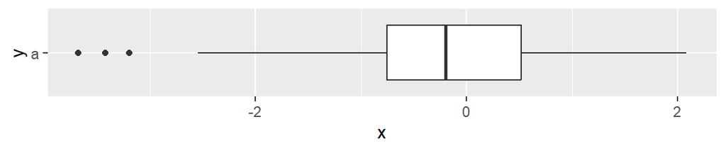

```r
data.frame(
  x=rnorm(120),
  y=letters[rep(1, 120)]) |>
  ggplot() +
  aes(x, y) + geom_boxplot()
```

I’m not sure if this is exactly 50 pixels, but it looks close.

## Calculations for two boxplots

You wouldn’t simply double the height from 1.25 to 2.5 inches. The margins wouldn’t need to be doubled. Also the number of gaps to keep two boxplots separated from one another and separated from the top and bottom edges of the plotting area does not double.

Here’s a rough calculation.

- 20 pixels image top to graphing area top
- 17 pixels graphing area top to first boxplot top
- 50 pixels first boxplot top to first boxplot bottom
- 17 pixels first boxplot bottom to second boxplot top
- 50 pixels second boxplot top to second boxplot bottom
- 17 pixels second boxplot bottom to graphing area bottom
- 60 pixels graphing area bottom to image bottom

This is a total of 231 pixels or 67 pixels more than what you need for the single boxplot.

## Test: two boxplots with a height of 1.75 inches

Let’s test this and see if the individual boxplots in an image with two boxplots have about the same 50 pixel height as the boxplot in an image with just one boxplot.

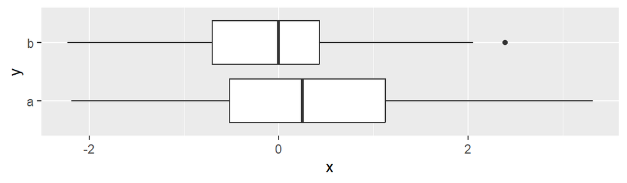

```r
data.frame(
  x=rnorm(120),
  y=letters[rep(1:2, 60)]) |>
  ggplot() +
  aes(x, y) +
  geom_boxplot()
```

## Test: three boxplots with 2.25 inches

Without doing all the tedious calculations, let’s hope that adding an additional 67 pixels (about another half inch) produces reasonable heights in an image with three boxplots.

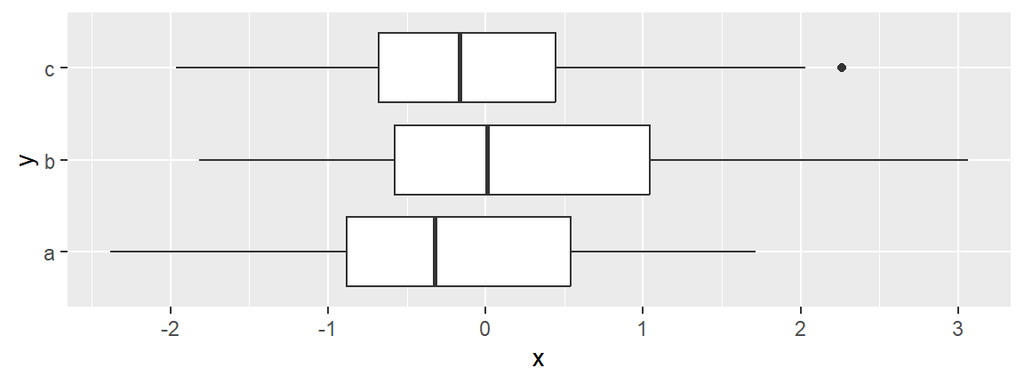

```r
data.frame(
  x=rnorm(120),
  y=letters[rep(1:3, 40)]) |>
  ggplot() +
  aes(x, y) +
  geom_boxplot()
```

## Test: four boxplots with 2.75 inches

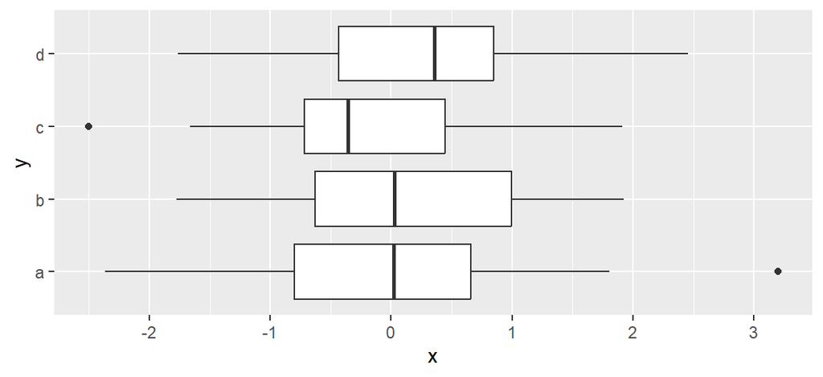

```r
data.frame(
  x=rnorm(120),
  y=letters[rep(1:4, 30)]) |>
  ggplot() +
  aes(x, y) +
  geom_boxplot()
```

## Test: five boxplots with 3.25 inches

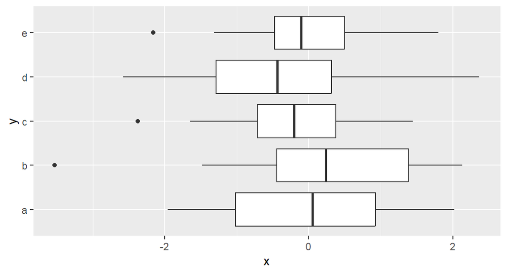

```r
data.frame(
  x=rnorm(120),
  y=letters[rep(1:5, 24)]) |>
  ggplot() +
  aes(x, y) +
  geom_boxplot()
```

## Test: six boxplots with 3.75 inches

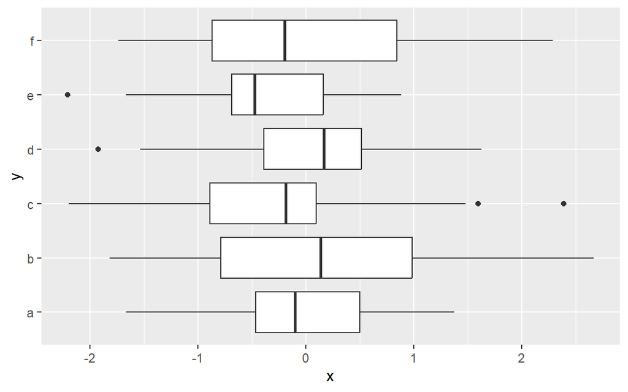

```r
data.frame(
  x=rnorm(120),
  y=letters[rep(1:6, 20)]) |>
  ggplot() +
  aes(x, y) +
  geom_boxplot()
```

There is a fixed amount of space at the top and bottom of every graph. On my system, this appears to take up about 80 pixels (20 at the top and 60 at the bottom). Also on my system, 80 pixels corresponds to about 0.625 inches. You may find a different amount here, depending on the labels on your axes, your titles, and possibly other factors.

Now add to that a certain amount of pixels that will produce a single nice looking boxplot. I like boxplots that are horizontal and fairly narrow. So a single boxplot looks good at about 0.5 inches plus the 0.625 inches for the margins. That means a total width of 1.125 inches.

There are gaps between the boxplots. With a single boxplot, there is a gap at the top and at the bottom. On my system, the gap looks like about 1/3 of the size of the box. So to get a boxplot of size x, you need a total of 5x/3. Setting 0.5 inches for the plot area corresponds to about 0.3 inches for the box itself.

With two boxplots, there are widths of 2x for the boxes, but there are three gaps: one above the first boxplot, one below the second boxplot and one between the two boxes. So two boxplots will take up 2x for the boxes and 3x/3 for the gaps, totaling to 3x. If you want each box to be 0.3 inches, set the total plot area to 0.9 inches and add in the 0.625 inches for the margins around the plot.

Wtih three boxplots, there are widths of 3x for the boxes and there are four gaps, leading to 3x +4x/3 = 13x/3. If you want each box to be 0.3 inches, set the plot area to 1.3 inches, plus 0.625 for the margins.